# Investigate a Target 2021 dataset

## by (siraj mortaja)

## Investigation Overview

> for EDA section i have 3 Questions and their Visualizations, first for univariate plot , second for bivariate, and another for multivariate plot.

> in the first plot i show the number of Projects in each Region for Region dataset by using groupby for Region and Project ID variables and value_counts functions then used bar plot.

> in the second plot i show the relationship between year and mean of budget of each year by using groupby function and scatter plot.

> in the third plot is view of all variables and their relationships with all other variables using seaborn lib.

## Dataset Overview

> the dataset i used is Target Dataset that contains one table , 14886 observations in the dataset with 16 features . There is 7 categorical variables (Business Line , Region , TBC Program , Mahdar Isnad ,TBC Ref , Project Name ,Data Tybe) and the others are numerical variables., to get these tables from a database I loaded it in a Data frame called data.

## (Visualization 1)

> the above plot show the number of Projects in each Region for Region dataset
> 1. X-axis is Regions
> 2. Y-axis is Number of Projects
> 3. conclusion that the largest number of projects for WST Region

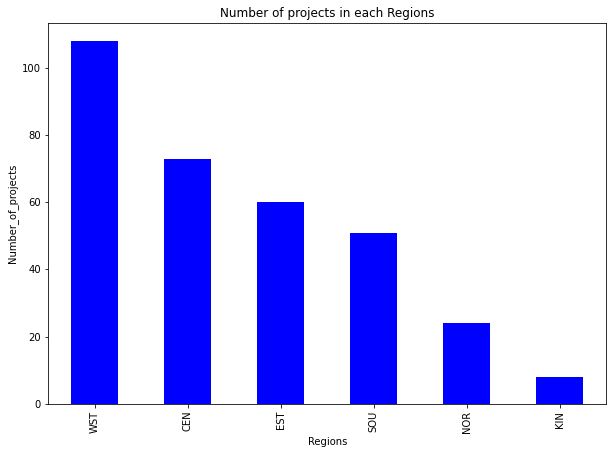

```python
Regions['Region'].value_counts().plot.bar(figsize=(10,7),color='b')
plt.xlabel('Regions')
plt.ylabel('Number_of_projects')
plt.title('Number of projects in each Regions')
```

## (Visualization 2)

#### the below plot show the relationship between year and mean of budget of each year

> 1. X-axis is year
> 2. Y-axis is budget
> 3. conclusion there is no correlation between year and mean of budget of each year in Target dataset.

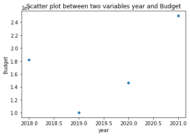

```python
data.groupby('year')['Budget'].mean().reset_index().plot.scatter(x='year', y='Budget', title= "Scatter plot between two variables year and Budget")
plt.show()
```

## (Visualization 3)

1. the below plot is view of all variables and their relationships with all other variables
2. here are strong relationships betwwen features and each other like (budget,total 2021) variables

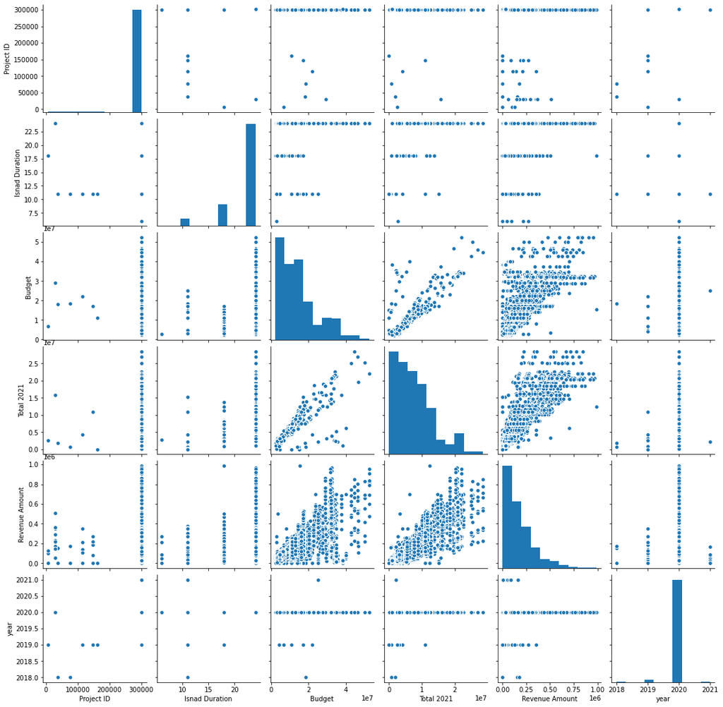

```python
sb.pairplot(data)
plt.show()
```